# Predicting Highly Rated IMDb Movies

Rylee Wang

# Project Overview

## Research Question

**Can movie metadata predict whether an IMDb movie receives an average rating of 7.0 or higher?**

This project uses four sampled IMDb datasets and compares logistic regression with a decision tree. The analysis looks for associations, not causal effects.

# Data

Place these files in the `data/` folder:

- `title.basics.csv`
- `title.akas.csv`
- `title.crew.csv`
- `title.ratings.tsv`

```r
basics <- read_csv(
  "data/title.basics.csv",
  show_col_types = FALSE
)

akas <- read_csv(
  "data/title.akas.csv",
  show_col_types = FALSE
)

crew <- read_csv(
  "data/title.crew.csv",
  show_col_types = FALSE
)

ratings <- read_tsv(
  "data/title.ratings.tsv",
  show_col_types = FALSE
)
```

# Data Preparation

```r
basics <- basics %>% rename(tid = 'title identifier')
akas <- akas %>% rename(tid = titleId)
crew <- crew %>% rename(tid = 'title identifier')
ratings <- ratings %>% rename(tid = tconst)
```

## Movie information

```r
movies <- basics %>%
  filter(titleType == "movie") %>%
  mutate(
    startYear = na_if(startYear, "\\N"),
    runtimeMinutes = na_if(runtimeMinutes, "\\N"),
    genres = na_if(genres, "\\N"),
    startYear = as.numeric(startYear),
    runtimeMinutes = as.numeric(runtimeMinutes),
    release_decade = floor(startYear / 10) * 10,
    primary_genre = str_extract(genres, "^[^,]+")
  ) %>%
  select(tid, primaryTitle, startYear, release_decade,
         runtimeMinutes, primary_genre)

nrow(movies)
```

```
## [1] 461
```

```r
glimpse(movies)
```

```
## Rows: 461
## Columns: 6
## $ tid            <chr> "tt0008014", "tt0008144", "tt0011127", "tt0012913", "tt…
## $ primaryTitle   <chr> "Gloria transita", "Jack and the Beanstalk", "Down Home…
## $ startYear      <dbl> 1917, 1917, 1920, 1922, 1922, 1922, 1927, 1931, 1931, 1…
## $ release_decade <dbl> 1910, 1910, 1920, 1920, 1920, 1920, 1920, 1930, 1930, 1…
## $ runtimeMinutes <dbl> 73, 100, 70, NA, 50, 70, 135, 83, 64, 71, 87, 74, 98, 5…
## $ primary_genre  <chr> NA, "Fantasy", "Drama", NA, "Western", "Comedy", "Drama…
```

## International-title coverage

```r
akas_summary <- akas %>%
  mutate(region = na_if(region, "\\N")) %>%
  group_by(tid) %>%
  summarize(
    n_akas = n(),
    n_regions = n_distinct(region, na.rm = TRUE),
    .groups = "drop"
  )

head(akas_summary)
```

```
## # A tibble: 6 × 3
##   tid       n_akas n_regions
##   <chr>      <int>     <int>
## 1 tt0003278      2         1
## 2 tt0003552      2         1
## 3 tt0004812      2         1
## 4 tt0008014      4         1
## 5 tt0008144      6         4
## 6 tt0009998      2         1
```

## Crew information

```r
crew_summary <- crew %>%
  transmute(
    tid,
    has_director = case_when(
      is.na(directors) ~ "No",
      directors == "\\N" ~ "No",
      TRUE ~ "Yes"
    ),
    has_writer = case_when(
      is.na(writers) ~ "No",
      writers == "\\N" ~ "No",
      TRUE ~ "Yes"
    )
  )

head(crew_summary)
```

```
## # A tibble: 6 × 3
##   tid       has_director has_writer
##   <chr>     <chr>        <chr>
## 1 tt0003278 Yes          Yes
## 2 tt0003552 Yes          No
## 3 tt0004812 Yes          Yes
## 4 tt0008014 Yes          Yes
## 5 tt0008144 Yes          Yes
## 6 tt0009998 Yes          Yes
```

## Final modeling dataset

```r
movie_data <- movies %>%
  inner_join(ratings, by = "tid") %>%
  left_join(akas_summary, by = "tid") %>%
  left_join(crew_summary, by = "tid") %>%
  mutate(
    n_akas = replace_na(n_akas, 0L),
    n_regions = replace_na(n_regions, 0L),
    has_director = replace_na(has_director, "No"),
    has_writer = replace_na(has_writer, "No"),
    high_rating = if_else(averageRating >= 7, "High", "Not High"),
    high_rating = factor(high_rating, levels = c("High", "Not High")),
    release_decade = factor(release_decade),
    primary_genre = factor(primary_genre),
    has_director = factor(has_director),
    has_writer = factor(has_writer)
  ) %>%
  filter(!is.na(startYear), !is.na(primary_genre)) %>%
  select(
    tid, primaryTitle, high_rating, averageRating, numVotes,
    startYear, release_decade, runtimeMinutes, primary_genre,
    n_akas, n_regions, has_director, has_writer
  )

glimpse(movie_data)
```

```
## Rows: 198
## Columns: 13
## $ tid            <chr> "tt0008144", "tt0011127", "tt0013562", "tt0018045", "tt…
## $ primaryTitle   <chr> "Jack and the Beanstalk", "Down Home", "Rounding Up the…
## $ high_rating    <fct> Not High, Not High, Not High, High, High, Not High, Not…
## $ averageRating  <dbl> 4.6, 6.4, 5.9, 7.0, 7.6, 5.4, 5.7, 5.8, 6.0, 4.8, 6.0, …
## $ numVotes       <dbl> 39, 42, 15, 348, 27, 112, 30, 9, 365, 65, 136, 81, 175,…
## $ startYear      <dbl> 1917, 1920, 1922, 1927, 1932, 1932, 1935, 1938, 1940, 1…
## $ release_decade <fct> 1910, 1920, 1920, 1920, 1930, 1930, 1930, 1930, 1940, 1…
## $ runtimeMinutes <dbl> 100, 70, 50, 135, 87, 74, 59, 93, 55, 67, 62, 56, 117, …
## $ primary_genre  <fct> Fantasy, Drama, Western, Drama, Comedy, Drama, Drama, R…
## $ n_akas         <int> 6, 4, 3, 21, 10, 9, 3, 7, 10, 5, 7, 4, 6, 3, 12, 22, 22…
## $ n_regions      <int> 4, 2, 2, 19, 8, 6, 2, 6, 8, 4, 6, 3, 5, 2, 9, 20, 20, 1…
## $ has_director   <fct> Yes, Yes, Yes, Yes, Yes, Yes, Yes, Yes, Yes, Yes, Yes, …
## $ has_writer     <fct> Yes, Yes, Yes, Yes, Yes, Yes, Yes, Yes, Yes, Yes, Yes, …
```

```r
nrow(movie_data)
```

```
## [1] 198
```

```r
count(movie_data, high_rating)
```

```
## # A tibble: 2 × 2
##   high_rating     n
##   <fct>       <int>
## 1 High           57
## 2 Not High      141
```

# Exploratory Data Analysis

## Rating distribution

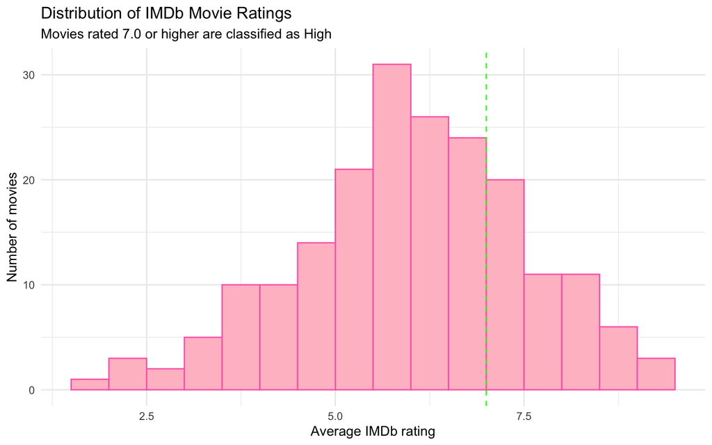

```r
rating_plot <- ggplot(movie_data, aes(x = averageRating)) +
  geom_histogram(binwidth = 0.5, boundary = 0, fill = "pink", color = "hotpink") +
  geom_vline(xintercept = 7, linetype = "dashed", color = "green") +
  labs(
    title = "Distribution of IMDb Movie Ratings",
    subtitle = "Movies rated 7.0 or higher are classified as High",
    x = "Average IMDb rating",
    y = "Number of movies"
  ) +
  theme_minimal()

rating_plot
```

```r
ggsave("figures/rating_distribution.png", rating_plot,
       width = 8, height = 5)
```

## Highly rated movies by genre

Because this is a small sample, genres only need at least five movies to appear in the graph.

```r
genre_summary <- movie_data %>%
  group_by(primary_genre) %>%
  summarize(
    movies = n(),
    high_rating_rate = mean(high_rating == "High"),
    mean_rating = mean(averageRating),
    .groups = "drop"
  ) %>%
  filter(movies >= 5) %>%
  arrange(desc(high_rating_rate))

genre_summary
```

```
## # A tibble: 7 × 4
##   primary_genre movies high_rating_rate mean_rating
##   <fct>          <int>            <dbl>       <dbl>
## 1 Documentary       17            0.765        7.46
## 2 Adventure          6            0.333        5.4
## 3 Comedy            36            0.278        6.16
## 4 Action            29            0.241        5.58
## 5 Drama             65            0.231        6.12
## 6 Horror            11            0.182        4.96
## 7 Crime              5            0            5.5
```

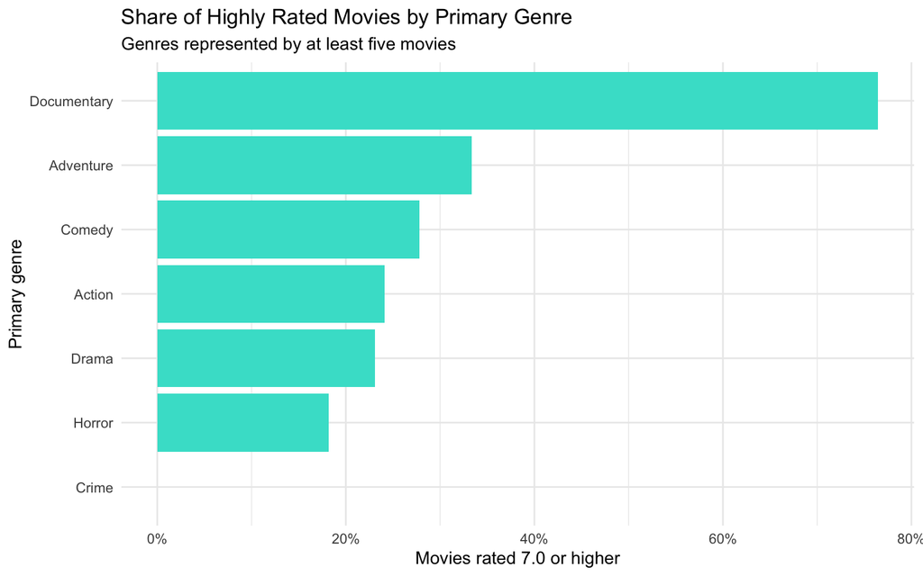

```r
genre_plot <- ggplot(
  genre_summary,
  aes(x = reorder(primary_genre, high_rating_rate),
      y = high_rating_rate)
) +
  geom_col(fill = "turquoise") +
  coord_flip() +
  scale_y_continuous(labels = scales::percent) +
  labs(
    title = "Share of Highly Rated Movies by Primary Genre",
    subtitle = "Genres represented by at least five movies",
    x = "Primary genre",
    y = "Movies rated 7.0 or higher"
  ) +
  theme_minimal()

genre_plot
```

```r
ggsave("figures/high_rating_by_genre.png", genre_plot,
       width = 8, height = 5)
```

## International coverage and ratings

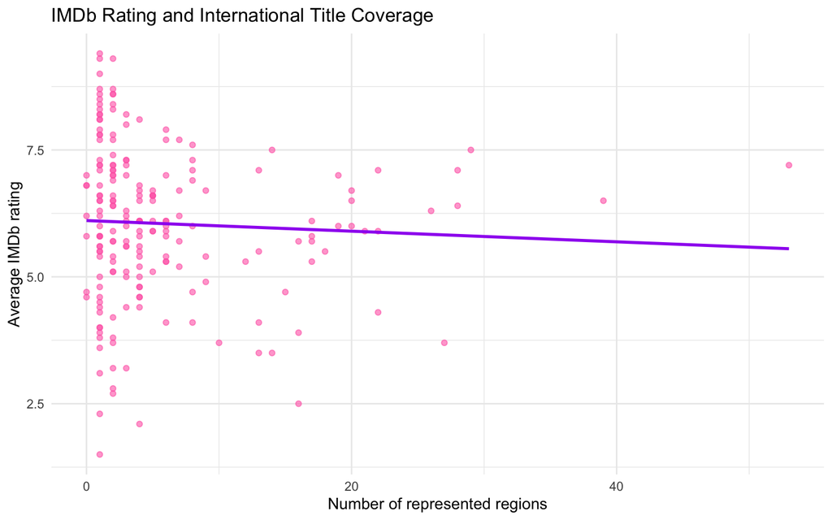

```r
coverage_plot <- ggplot(movie_data, aes(x = n_regions, y = averageRating)) +
  geom_point(alpha = 0.6, color = "hotpink") +
  geom_smooth(method = "lm", se = FALSE, color = "purple") +
  labs(
    title = "IMDb Rating and International Title Coverage",
    x = "Number of represented regions",
    y = "Average IMDb rating"
  ) +
  theme_minimal()

coverage_plot
```

```r
ggsave("figures/coverage_vs_rating.png", coverage_plot,
       width = 8, height = 5)
```

# Train/Test Split

```r
set.seed(123)
movie_split <- initial_split(movie_data, prop = 0.80,
                             strata = high_rating)
movie_train <- training(movie_split)
movie_test <- testing(movie_split)
count(movie_train, high_rating)
```

```
## # A tibble: 2 × 2
##   high_rating     n
##   <fct>       <int>
## 1 High           45
## 2 Not High      112
```

```r
count(movie_test, high_rating)
```

```
## # A tibble: 2 × 2
##   high_rating     n
##   <fct>       <int>
## 1 High           12
## 2 Not High       29
```

# Preprocessing

```r
movie_recipe <- recipe(
  high_rating ~ runtimeMinutes + release_decade + primary_genre +
    n_akas + n_regions + has_director + has_writer,
  data = movie_train
) %>%
  step_impute_median(all_numeric_predictors()) %>%
  step_novel(all_nominal_predictors()) %>%
  step_unknown(all_nominal_predictors()) %>%
  step_other(primary_genre, threshold = 0.03) %>%
  step_dummy(all_nominal_predictors()) %>%
  step_zv(all_predictors()) %>%
  step_normalize(all_numeric_predictors())

movie_recipe
```

# Model 1: Logistic Regression

```r
logistic_model <- logistic_reg() %>%
  set_engine("glm") %>%
  set_mode("classification")

logistic_workflow <- workflow() %>%
  add_recipe(movie_recipe) %>%
  add_model(logistic_model)

logistic_fit <- fit(logistic_workflow, data = movie_train)
logistic_fit
```

```
## ══ Workflow [trained] ══════════════════════════════════════════════════════════
## Preprocessor: Recipe
## Model: logistic_reg()
##
## ── Preprocessor ────────────────────────────────────────────────────────────────
## 7 Recipe Steps
##
## • step_impute_median()
## • step_novel()
## • step_unknown()
## • step_other()
## • step_dummy()
## • step_zv()
## • step_normalize()
##
## ── Model ───────────────────────────────────────────────────────────────────────
##
## Call:  stats::glm(formula = ..y ~ ., family = stats::binomial, data = data)
##
## Coefficients:
##               (Intercept)             runtimeMinutes
##                   2.44013                   -0.63253
##                    n_akas                  n_regions
##                  -0.87237                    1.30286
##      release_decade_X1920       release_decade_X1930
##                  -0.11253                   -2.94197
##      release_decade_X1940       release_decade_X1950
##                  -3.49902                   -0.20142
##      release_decade_X1960       release_decade_X1970
##                  -3.35927                   -4.87675
##      release_decade_X1980       release_decade_X1990
##                  -5.41736                   -3.93908
##      release_decade_X2000       release_decade_X2010
##                  -5.77485                   -7.20375
##      release_decade_X2020       primary_genre_Comedy
##                  -6.30958                   -0.32243
## primary_genre_Documentary        primary_genre_Drama
##                  -0.87551                   -0.01563
##      primary_genre_Horror        primary_genre_other
##                   3.33821                   -0.06554
##          has_director_Yes             has_writer_Yes
##                  -0.12543                    0.10631
##
## Degrees of Freedom: 156 Total (i.e. Null);  135 Residual
## Null Deviance:       188.1
## Residual Deviance: 142.5     AIC: 186.5
```

# Model 2: Decision Tree

```r
tree_model <- decision_tree(
  tree_depth = 4,
  min_n = 10,
  cost_complexity = 0.01
) %>%
  set_engine("rpart") %>%
  set_mode("classification")

tree_workflow <- workflow() %>%
  add_recipe(movie_recipe) %>%
  add_model(tree_model)

tree_fit <- fit(tree_workflow, data = movie_train)
tree_fit
```

```
## ══ Workflow [trained] ══════════════════════════════════════════════════════════
## Preprocessor: Recipe
## Model: decision_tree()
##
## ── Preprocessor ────────────────────────────────────────────────────────────────
## 7 Recipe Steps
##
## • step_impute_median()
## • step_novel()
## • step_unknown()
## • step_other()
## • step_dummy()
## • step_zv()
## • step_normalize()
##
## ── Model ───────────────────────────────────────────────────────────────────────
## n= 157
##
## node), split, n, loss, yval, (yprob)
##       * denotes terminal node
##
##  1) root 157 45 Not High (0.28662420 0.71337580)
##    2) primary_genre_Documentary>=1.371502 15  3 High (0.80000000 0.20000000)
##      4) runtimeMinutes>=-1.619115 12  1 High (0.91666667 0.08333333) *
##      5) runtimeMinutes< -1.619115 3  1 Not High (0.33333333 0.66666667) *
##    3) primary_genre_Documentary< 1.371502 142 33 Not High (0.23239437 0.76760563)
##      6) runtimeMinutes>=0.7981204 24 12 High (0.50000000 0.50000000)
##       12) primary_genre_Drama>=0.2838661 16  6 High (0.62500000 0.37500000)
##         24) n_akas>=-0.4962398 7  1 High (0.85714286 0.14285714) *
##         25) n_akas< -0.4962398 9  4 Not High (0.44444444 0.55555556) *
##       13) primary_genre_Drama< 0.2838661 8  2 Not High (0.25000000 0.75000000) *
##      7) runtimeMinutes< 0.7981204 118 21 Not High (0.17796610 0.82203390)
##       14) n_akas< -0.3728675 52 16 Not High (0.30769231 0.69230769)
##         28) release_decade_X2020>=0.9615625 7  1 High (0.85714286 0.14285714) *
##         29) release_decade_X2020< 0.9615625 45 10 Not High (0.22222222 0.77777778) *
##       15) n_akas>=-0.3728675 66  5 Not High (0.07575758 0.92424242) *
```

# Predictions

```r
make_predictions <- function(fitted_workflow, test_data) {
  test_data %>%
    select(tid, primaryTitle, high_rating) %>%
    bind_cols(predict(fitted_workflow, new_data = test_data,
                      type = "class")) %>%
    bind_cols(predict(fitted_workflow, new_data = test_data,
                      type = "prob"))
}

logistic_predictions <- make_predictions(logistic_fit, movie_test)
tree_predictions <- make_predictions(tree_fit, movie_test)
```

# Model Evaluation

```r
classification_metrics <- metric_set(
  accuracy, bal_accuracy, precision, recall, f_meas
)

logistic_metrics <- classification_metrics(
  logistic_predictions,
  truth = high_rating,
  estimate = .pred_class,
  event_level = "first"
) %>% mutate(model = "Logistic Regression")

tree_metrics <- classification_metrics(
  tree_predictions,
  truth = high_rating,
  estimate = .pred_class,
  event_level = "first"
) %>% mutate(model = "Decision Tree")

logistic_auc <- roc_auc(
  logistic_predictions,
  truth = high_rating,
  .pred_High,
  event_level = "first"
) %>% mutate(model = "Logistic Regression")

tree_auc <- roc_auc(
  tree_predictions,
  truth = high_rating,
  .pred_High,
  event_level = "first"
) %>% mutate(model = "Decision Tree")

model_results <- bind_rows(
  logistic_metrics, tree_metrics, logistic_auc, tree_auc
) %>% select(model, .metric, .estimate)

model_results
```

```
## # A tibble: 12 × 3
##    model               .metric      .estimate
##    <chr>               <chr>            <dbl>
##  1 Logistic Regression accuracy         0.683
##  2 Logistic Regression bal_accuracy     0.532
##  3 Logistic Regression precision        0.4
##  4 Logistic Regression recall           0.167
##  5 Logistic Regression f_meas           0.235
##  6 Decision Tree       accuracy         0.732
##  7 Decision Tree       bal_accuracy     0.566
##  8 Decision Tree       precision        0.667
##  9 Decision Tree       recall           0.167
## 10 Decision Tree       f_meas           0.267
## 11 Logistic Regression roc_auc          0.483
## 12 Decision Tree       roc_auc          0.611
```

## Model comparison

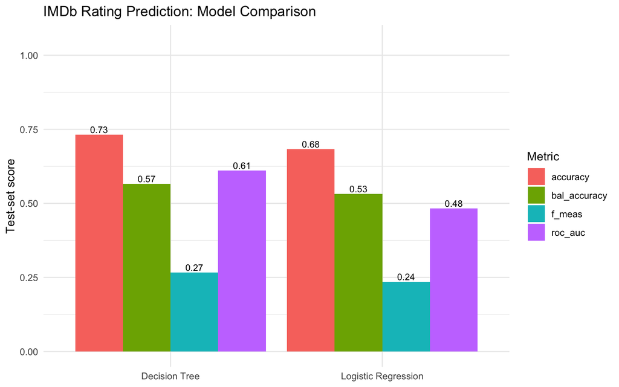

```r
comparison_plot <- model_results %>%
  filter(.metric %in% c("accuracy", "bal_accuracy", "f_meas", "roc_auc")) %>%
  ggplot(aes(x = model, y = .estimate, fill = .metric)) +
  geom_col(position = "dodge") +
  geom_text(
    aes(label = round(.estimate, 2)),
    position = position_dodge(width = 0.9),
    vjust = -0.3,
    size = 3
  ) +
  coord_cartesian(ylim = c(0, 1.05)) +
  labs(
    title = "IMDb Rating Prediction: Model Comparison",
    x = NULL,
    y = "Test-set score",
    fill = "Metric"
  ) +
  theme_minimal()

comparison_plot
```

```r
ggsave("figures/model_comparison.png", comparison_plot,
       width = 9, height = 5)
```

## Confusion matrices

```r
logistic_confusion <- conf_mat(
  logistic_predictions,
  truth = high_rating,
  estimate = .pred_class
)

tree_confusion <- conf_mat(
  tree_predictions,
  truth = high_rating,
  estimate = .pred_class
)

logistic_confusion
```

```
##           Truth
## Prediction High Not High
##   High        2        3
##   Not High   10       26
```

```r
tree_confusion
```

```
##           Truth
## Prediction High Not High
##   High        2        1
##   Not High   10       28
```

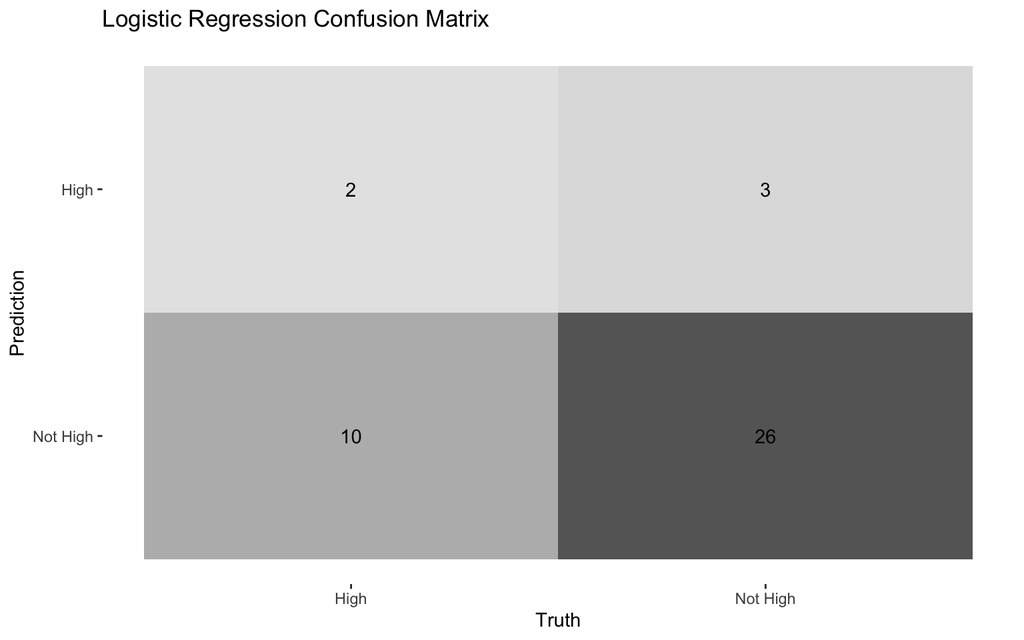

```r
autoplot(logistic_confusion, type = "heatmap") +
  labs(title = "Logistic Regression Confusion Matrix")
```

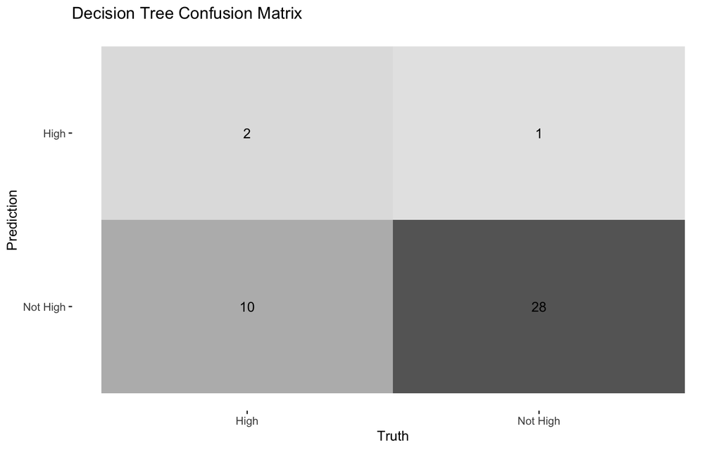

```r
autoplot(tree_confusion, type = "heatmap") +
  labs(title = "Decision Tree Confusion Matrix")
```

## ROC curves

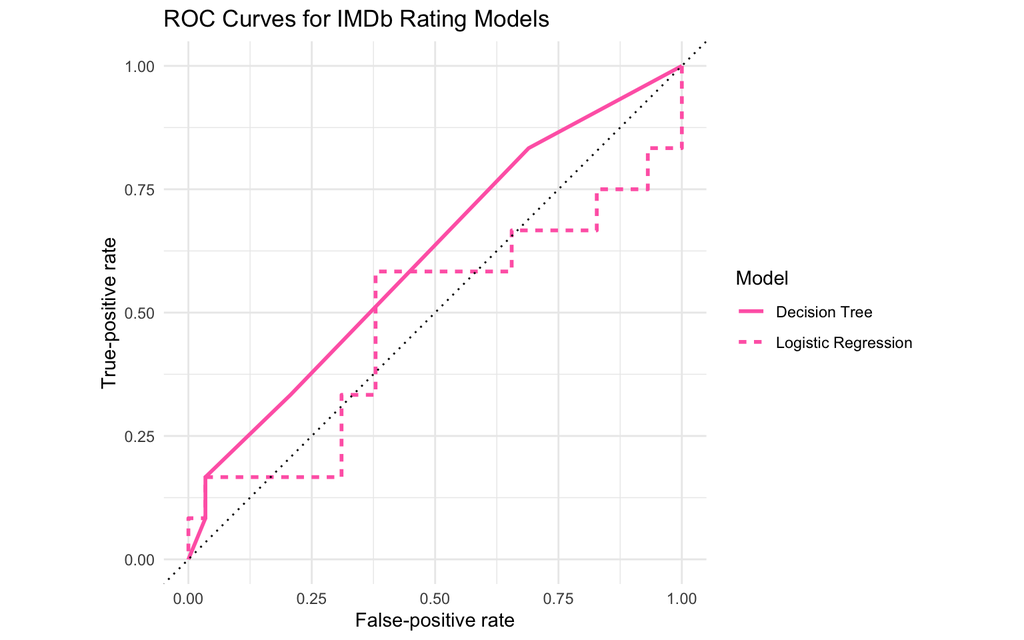

```r
logistic_roc <- roc_curve(
  logistic_predictions,
  truth = high_rating,
  .pred_High,
  event_level = "first"
) %>% mutate(model = "Logistic Regression")

tree_roc <- roc_curve(
  tree_predictions,
  truth = high_rating,
  .pred_High,
  event_level = "first"
) %>% mutate(model = "Decision Tree")

roc_plot <- bind_rows(logistic_roc, tree_roc) %>%
  ggplot(aes(x = 1 - specificity, y = sensitivity,
             linetype = model)) +
  geom_path(linewidth = 1, color = "hotpink") +
  geom_abline(linetype = "dotted") +
  coord_equal() +
  labs(
    title = "ROC Curves for IMDb Rating Models",
    x = "False-positive rate",
    y = "True-positive rate",
    linetype = "Model"
  ) +
  theme_minimal()

roc_plot
```

```r
ggsave("figures/roc_curves.png", roc_plot,
       width = 7, height = 6)
```

# Decision Tree Visualization

[figure not shown]

```r
fitted_tree <- extract_fit_engine(tree_fit)
rpart.plot(
  fitted_tree,
  type = 3,
  extra = 104,
  fallen.leaves = TRUE,
  main = "Decision Tree for Predicting High IMDb Ratings"
)
```

# Cross-Validation

```r
set.seed(123)
movie_folds <- vfold_cv(movie_train, v = 5,
                        strata = high_rating)
cv_metrics <- metric_set(accuracy, bal_accuracy, roc_auc)

logistic_cv <- fit_resamples(
  logistic_workflow,
  resamples = movie_folds,
  metrics = cv_metrics,
  control = control_resamples(save_pred = TRUE)
)

tree_cv <- fit_resamples(
  tree_workflow,
  resamples = movie_folds,
  metrics = cv_metrics,
  control = control_resamples(save_pred = TRUE)
)

logistic_cv_results <- collect_metrics(logistic_cv) %>%
  mutate(model = "Logistic Regression")

tree_cv_results <- collect_metrics(tree_cv) %>%
  mutate(model = "Decision Tree")

bind_rows(logistic_cv_results, tree_cv_results) %>%
  select(model, .metric, mean, std_err)
```

```
## # A tibble: 6 × 4
##   model               .metric       mean std_err
##   <chr>               <chr>        <dbl>   <dbl>
## 1 Logistic Regression accuracy     0.700  0.0465
## 2 Logistic Regression bal_accuracy 0.597  0.0544
## 3 Logistic Regression roc_auc      0.609  0.0513
## 4 Decision Tree       accuracy     0.777  0.0272
## 5 Decision Tree       bal_accuracy 0.690  0.0315
## 6 Decision Tree       roc_auc      0.718  0.0436
```

# Error Analysis

```r
logistic_errors <- logistic_predictions %>%
  filter(high_rating != .pred_class) %>%
  left_join(
    movie_data %>%
      select(tid, averageRating, runtimeMinutes,
             release_decade, primary_genre, n_regions),
    by = "tid"
  ) %>%
  arrange(desc(.pred_High))

head(logistic_errors, 15)
```

```
## # A tibble: 13 × 11
##    tid        primaryTitle   high_rating .pred_class .pred_High `.pred_Not High`
##    <chr>      <chr>          <fct>       <fct>            <dbl>            <dbl>
##  1 tt7564064  Lady You Shot… Not High    High           8.57e-1            0.143
##  2 tt23644054 Top Gear       Not High    High           5.67e-1            0.433
##  3 tt0083820  Desh Premee    Not High    High           5.03e-1            0.497
##  4 tt8661880  It Must Schwi… High        Not High       3.16e-1            0.684
##  5 tt0314096  This Is Gary … High        Not High       3.06e-1            0.694
##  6 tt1445206  Discover the … High        Not High       2.67e-1            0.733
##  7 tt9436648  Marconi        High        Not High       2.47e-1            0.753
##  8 tt0473114  Ah Müjgân Ah   High        Not High       2.35e-1            0.765
##  9 tt1355638  The Rabbi's C… High        Not High       9.76e-2            0.902
## 10 tt0018045  The Chess Pla… High        Not High       7.28e-8            1.000
## 11 tt10556402 Kutuk          High        Not High       2.16e-8            1.000
## 12 tt2066896  Iron Curtain   High        Not High       9.02e-9            1.000
## 13 tt0053285  Sleeping Beau… High        Not High       2.99e-9            1.000
## # ℹ 5 more variables: averageRating <dbl>, runtimeMinutes <dbl>,
## #   release_decade <fct>, primary_genre <fct>, n_regions <int>
```

# Results

The logistic regression model achieved:

- Accuracy: **0.683**
- Balanced accuracy: **0.532**
- F1 score: **0.235**
- ROC-AUC: **0.483**

The decision tree achieved:

- Accuracy: **0.732**
- Balanced accuracy: **0.566**
- F1 score: **0.267**
- ROC-AUC: **0.611**

Based on **ROC-AUC**, the **decision tree** performed better. Because the dataset is a small sample, the findings should be treated as exploratory.

# Limitations

1. The dataset is a course-provided sample rather than the complete IMDb database.
2. Some movies are missing ratings, runtime, genre, or crew information.
3. The 7.0 cutoff is a project-defined threshold.
4. IMDb ratings can change over time.
5. The model does not include budget, cast popularity, marketing, critic reviews, or release strategy.
6. The models identify associations, not causal relationships.

# Conclusion

This project demonstrates relational joins, data cleaning, feature engineering, visualization, logistic regression, decision trees, cross-validation, model evaluation, and error analysis in R.